# Multilevel Modelling – Practical 2 (Week 3)

## Exercise 3 (if time)

The data used here represent Maths achievement scores of a subsample of subjects from the 1982 High School and Beyond Survey. The full dataset can be found within the package [merTools](https://rdrr.io/cran/merTools/man/hsb.html). Click the link to read about the data set.

The analysis starts by introducing the data and producing some visual representations.

Read in the data from Andy’s Github page with

```r
sub_hsb <-
   read.csv(file="https://andygolightly.github.io/teaching/MATH43515/sub_hsb.csv")
```

Carry out the following operations for simple access of variables.

```r
data <- sub_hsb
mathach <- data$mathach # Maths achievement score (response)
ses <- data$ses
female <- data$female
school.f <- as.factor(data$schid)
```

Data inspection:

```r
head(data)
```

|  | schid | minority | female | ses | mathach | size | schtype | meanses |
| --- | --- | --- | --- | --- | --- | --- | --- | --- |
| 1 | 1224 | 0 | 1 | -1.528 | 5.876 | 842 | 0 | -0.428 |
| 2 | 1224 | 0 | 1 | -0.588 | 19.708 | 842 | 0 | -0.428 |
| 3 | 1224 | 0 | 0 | -0.528 | 20.349 | 842 | 0 | -0.428 |
| 4 | 1224 | 0 | 0 | -0.668 | 8.781 | 842 | 0 | -0.428 |
| 5 | 1224 | 0 | 0 | -0.158 | 17.898 | 842 | 0 | -0.428 |
| 6 | 1224 | 0 | 0 | 0.022 | 4.583 | 842 | 0 | -0.428 |

Start with a linear regression as a baseline model.

```r
lm <- lm(mathach~ses, data=data)

summary(lm)
```

```
##
## Call:
## lm(formula = mathach ~ ses, data = data)
##
## Residuals:
##      Min       1Q   Median       3Q      Max
## -18.0019  -4.6006   0.0497   5.2174  16.0877
##
## Coefficients:
##             Estimate Std. Error t value Pr(>|t|)
## (Intercept)  12.8864     0.1753   73.51   <2e-16 ***
## ses           3.4530     0.2222   15.54   <2e-16 ***
## ---
## Signif. codes:  0 '***' 0.001 '**' 0.01 '*' 0.05 '.' 0.1 ' ' 1
##
## Residual standard error: 6.39 on 1327 degrees of freedom
## Multiple R-squared:  0.1539, Adjusted R-squared:  0.1533
## F-statistic: 241.5 on 1 and 1327 DF,  p-value: < 2.2e-16
```

Visualise the linear relationship.

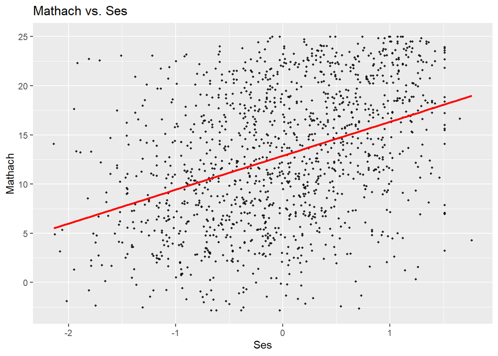

```r
ggplot(data  = data, aes(x = ses, y = mathach))+
  geom_point(size = 0.8, alpha = .8)+
  geom_smooth(method="lm", se=FALSE, col="Red")+
  ggtitle("Mathach vs. Ses") +
  xlab("Ses") +
  ylab("Mathach")
```

Carry out further exploratory analysis of the data along the lines of the previous example.

```r
# ...
```

End of lab!